# lab7_HamnaAshraf

## Lab7 - Performance Metrics for Classification:

### Hamna Ashraf - 8826836

**Required Libraries:**

```python
from sklearn.datasets import fetch_openml
import matplotlib.pyplot as plt
import numpy as np
import matplotlib as mt
from sklearn.model_selection import train_test_split
from sklearn.linear_model import LogisticRegression
from sklearn.pipeline import make_pipeline
from sklearn.preprocessing import StandardScaler
from sklearn.metrics import confusion_matrix, accuracy_score, classification_report, precision_recall_curve, precision_score, recall_score
from sklearn.dummy import DummyClassifier
```

### 1. Getting the MNIST data:

```python
mnist = fetch_openml('mnist_784', as_frame=False, parser='auto')
```

### 2. Performing EDA:

```python
mnist.data.shape
```

```
(70000, 784)
```

It shows us that there are 70,000 images (features) in our dataset. Each feature i.e image has 784 attributes which are the pixels of an image (dimension: 28 x 28). These attributes range from 0-255, which shows how dark each pixel is where 0 shows white and 255 shows black.

```python
mnist.target.shape
```

```
(70000,)
```

this is just to be sure that all the images have target or label associated to it. There are 70,000 images (features) therefore 70,000 target

```python
mnist.keys()
```

```
dict_keys(['data', 'target', 'frame', 'categories', 'feature_names', 'target_names', 'DESCR', 'details', 'url'])
```

The mnist data fetched has these keys. We can use these to know details about it.

```python
mnist.categories
```

```
{'class': ['0', '1', '2', '3', '4', '5', '6', '7', '8', '9']}
```

This shows us that range of categories is from 0-9. It means that the the images found in the dataset are from classes 0 - 9.

```
<BarContainer object of 10 artists>
```

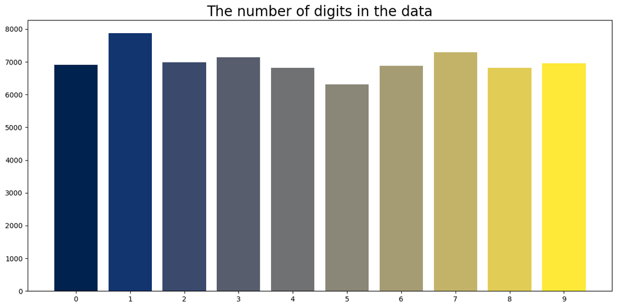

```python
labels, counts = np.unique(mnist.target, return_counts=True)

digit_range = np.arange(10)

cmap = mt.colormaps['cividis']
colors = cmap(np.linspace(0, 1, len(labels)))

plt.figure(figsize=(15, 7))
plt.title("The number of digits in the data", fontsize=20)
plt.xticks(range(10))
plt.bar(labels, counts, color = colors)

#Kaggle Notebook reference: https://www.kaggle.com/code/jedrzejdudzicz/mnist-dataset-100-accuracy
```

```python
for label, count in zip(labels, counts):
    print(f"Label {label}: {count} samples")
```

```
Label 0: 6903 samples
Label 1: 7877 samples
Label 2: 6990 samples
Label 3: 7141 samples
Label 4: 6824 samples
Label 5: 6313 samples
Label 6: 6876 samples
Label 7: 7293 samples
Label 8: 6825 samples
Label 9: 6958 samples
```

From this we can verify that label 1 has the most occurance having 7877 samples in the dataset.

Reference for the code below is taken from the class notebook: https://github.com/CSCN8010/CSCN8010/blob/main/class_notebooks/classification-performance-metrics/performance_metrics_for_classification.ipynb

```python
#Renaming:

data = mnist.data
target = mnist.target
```

```python
def plot_digit(image_data): #1D having all values of image
    image = image_data.reshape(28, 28)
    plt.imshow(image, cmap="binary") #color map, plot in greyscale
    plt.axis("off")

#function to display image retrived from class_notebook
```

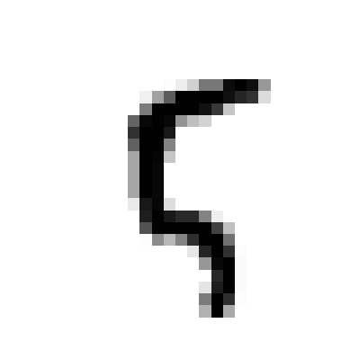

```python
some_digit = data[100]  # here we are using the 100th image in the dataset
plot_digit(some_digit)
plt.show()
```

```python
target[100]
```

```
'5'
```

The target for the 100th image is 5 which we can see in the data image too.

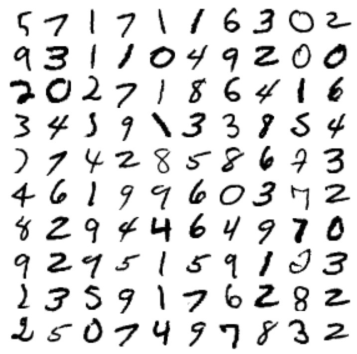

```python
plt.figure(figsize=(9, 9))
for idx, image_data in enumerate(data[100:200]):
    plt.subplot(10, 10, idx + 1)
    plot_digit(image_data)
plt.subplots_adjust(wspace=0, hspace=0)
plt.show()
```

We already saw the 1-100 images in the class notebook. Here I printed images from 100 - 200.  
This is a way to get familiar with the data and know how it looks like.

```python
print(mnist.DESCR)
```

[output not shown]

The DESCR key has value that describes the mnist dataset. This includes it's author, source and detailed overview of what the mnist dataset is. This is how we can have even more clarity on the data that we are dealing with. These insights will help us perform meaningful analysis and train the model accordingly.

### 3. Chose four classes and validated:

```python
#Took help from chatgpt to perform this step. Tried to implement on my own but wasn't successful

#Convert the existing target to int
target = target.astype(int)

#I've taken 4 classes as given below
classes = [0, 1, 2, 3]

mask = np.isin(target, classes)

# Apply the mask to filter data and targets
new_data = data[mask]
new_targets = target[mask]
```

**Validate the data and targets:**

```
Classes selected: [0, 1, 2, 3]
Filtered data shape: (28911, 784)
Filtered targets shape: (28911,)
```

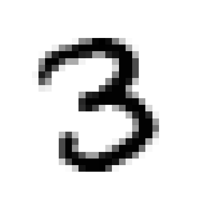

```
3
```

```python
print(f"Classes selected: {classes}")

print(f"Filtered data shape: {new_data.shape}")
print(f"Filtered targets shape: {new_targets.shape}")

some_digit = new_data[2001]
plot_digit(some_digit)
plt.show()

print(new_targets[2001])
```

Out of 10 classes, I chose to take 4. The shape reduced from 70,000 to 28911. To validate that the data aligns with the target, plotted a random image at index 2001. Both data and target are the same

### 4. Split data:

```python
X_train, X_temp, y_train, y_temp = train_test_split(new_data, new_targets, test_size = 0.3, random_state=42)

# Split the temp set into validation and test sets
X_validate, X_test, y_validate, y_test = train_test_split(X_temp, y_temp, test_size=0.5, random_state=42)
```

### 5. Choose a model:

```python
pipe = make_pipeline(StandardScaler(), LogisticRegression(solver = 'lbfgs', max_iter= 2000 ,random_state=42))
pipe.fit(X_train, y_train)

#https://scikit-learn.org/stable/modules/preprocessing.html
```

```
Pipeline(steps=[('standardscaler', StandardScaler()),
                ('logisticregression',
                 LogisticRegression(max_iter=2000, random_state=42))])
```

The code given earlier is different from how we normally perform logistic regression. It gave me a warning that the max_limit reached and failed to coverge. Therefore, we used an alternative method. In it, **Standard Scaler** is a pre-processing step used for *standarizing features*. **Solver** is an algorithm used for *optimization* and it is used commonly for logistic regression. I tried others, but this was working best and took the least time to train. I increased the number of iterations because till 1500 max iteration limit, it gave failed to converge warning.

### 6. Evaluation on validation dataset:

```python
y_pred = pipe.predict(X_validate)
y_pred.data
y_pred.shape
```

```
(4337,)
```

```python
dummy_clf = DummyClassifier()
dummy_clf.fit(X_train, y_train)
```

```
DummyClassifier()
```

**Accuracy:**

```python
accuracy = accuracy_score(y_validate, y_pred)
print(f"Accuracy: {accuracy:.4f}")
```

```
Accuracy: 0.9603
```

After running the model it gives us 96% accuracy on the validation data for the classes that we chose.

**Confusion Matrix:**

```python
conf_matrix = confusion_matrix(y_validate, y_pred)
print("Confusion Matrix:")
print(conf_matrix)
```

```
Confusion Matrix:
[[1007    1   14    5]
 [   2 1159   10    9]
 [  13   11  972   38]
 [  13   13   43 1027]]
```

We can see that the numbers in diagonal are the ones that are correctly predicted for each class.

```python
y_train_perfect_predictions = y_validate
confusion_matrix(y_validate, y_train_perfect_predictions)

#Took help from the class notebook for this
```

```
array([[1027,    0,    0,    0],
       [   0, 1180,    0,    0],
       [   0,    0, 1034,    0],
       [   0,    0,    0, 1096]], dtype=int64)
```

This confusion matrix makes us better to understand the actual values and predictions

**Precision and Recall:**

```python
report = classification_report(y_validate, y_pred, output_dict=False)
print("For Each Class:\n", report)
```

```
For Each Class:
               precision    recall  f1-score   support

           0       0.97      0.98      0.98      1027
           1       0.98      0.98      0.98      1180
           2       0.94      0.94      0.94      1034
           3       0.95      0.94      0.94      1096

    accuracy                           0.96      4337
   macro avg       0.96      0.96      0.96      4337
weighted avg       0.96      0.96      0.96      4337
```

We can see that the precision, recall and f1score for class 0 and 1 is around 98%. However it is relatively lower for classes 2 and 3 which is almost 94%.

```python
y_val_3 = (y_validate == 3)  # True for all 3s, False for all other digits
```

```python
y_scores = pipe.predict_proba(X_validate)[:, 3]  # Assuming class '3' is at index 3
precisions, recalls, thresholds = precision_recall_curve(y_val_3, y_scores)
```

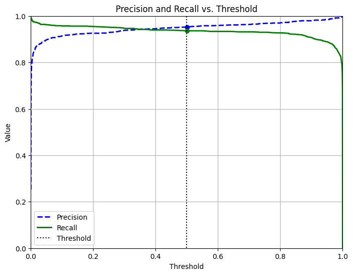

```python
threshold = 0.5
plt.figure(figsize=(8, 6))

plt.plot(thresholds, precisions[:-1], "b--", label="Precision", linewidth=2)
plt.plot(thresholds, recalls[:-1], "g-", label="Recall", linewidth=2)

plt.vlines(threshold, plt.ylim()[0], plt.ylim()[1], colors="k", linestyles="dotted", label='Threshold')

idx = (thresholds >= threshold).argmax()
plt.scatter(thresholds[idx], precisions[idx], c="b", marker="o")
plt.scatter(thresholds[idx], recalls[idx], c="g", marker="o")

plt.xlim([thresholds.min(), thresholds.max()])
plt.ylim([0, 1])

plt.xlabel("Threshold")
plt.ylabel("Value")
plt.legend(loc="lower left")
plt.grid(True)
plt.title("Precision and Recall vs. Threshold")
plt.show()
```

The graph shows the precision-recall curve for class 3.  
Precision measures the positive predictions made by the model where as recall shows that from all positives how many did we get correct.  
In the graph where threshold is 0.5, it shows the precision and recall for class 3

### 7. Increased precision and increased recall for chosen class:

```python
threshold = 0.6
y_pred_high_precision = (y_scores > threshold)

precision = precision_score(y_val_3, y_pred_high_precision)
recall = recall_score(y_val_3, y_pred_high_precision)

print(f"When threshold increased to: {threshold}\nPrecision: {precision:.4f}\nRecall: {recall:.4f}")
```

```
When threshold increased to: 0.6
Precision: 0.9597
Recall: 0.9334
```

```python
threshold = 0.3
y_pred_high_recall = (y_scores > threshold)

precision = precision_score(y_val_3, y_pred_high_recall)
recall = recall_score(y_val_3, y_pred_high_recall)

print(f"When threshold decreased to: {threshold}\nPrecision: {precision:.4f}\nRecall: {recall:.4f}")
```

```
When threshold decreased to: 0.3
Precision: 0.9385
Recall: 0.9471
```

When the threshold value is decreased, recall increases whereas precision decreases.  
It is because all those which had low predicted probability of will also be classified as positive.

### 8. Run on test data:

```python
y_pred_test = pipe.predict(X_test)

report = classification_report(y_test, y_pred_test, output_dict=False)
print("For Each Class:\n", report)
```

```
For Each Class:
               precision    recall  f1-score   support

           0       0.98      0.98      0.98      1045
           1       0.96      0.97      0.97      1151
           2       0.94      0.93      0.94      1078
           3       0.94      0.94      0.94      1063

    accuracy                           0.96      4337
   macro avg       0.96      0.96      0.96      4337
weighted avg       0.96      0.96      0.96      4337
```

**Conclusion:** When running our model on test data, we get almost similar results like we got on the validation data i.e 96% accuracy.  
This means that our model did well in predicting 4 class [0,1,2,3] and overall 96% accurate predictions of both positive and negative classes.  
The precision and recall was a bit lower for classes 2 and 3 compared to the results we got for classes 0 and 1.

Therefore, we can say that our model performed well overall. It is because the results were no different from the validation results.